# Healthcare

Tanvi Arora

July 15, 2018

## Mental Health Clinics

This data set is a survey of every known healthcare facility that offers mental health services in the United States in 2015.Downloaded from (SAMHDA)[https://datafiles.samhsa.gov/study-dataset/national-mental-health-services-survey-2015-n-mhss-2015-ds0001-nid17098]

**a - load the dataset**

```r
#load samhda dataset
#data is downloaded manually from the site as .rda file and is loaded to R global environment

f<- load(file = "C:/Users/tanvi/Documents/SMU/Assignments/MSDS 6306 - Doing DataScience/Unit10/N-MHSS-2015-DS0001-bndl-data-r/N-MHSS-2015-DS0001-data/N-MHSS-2015-DS0001-data-r.rda")
head(f)
```

```
## [1] "mh2015_puf"
```

```r
#get first few records of the dataset
#head(mh2015_puf)

# structure of the dataset
#str(mh2015_puf)

# keep a backup of original dataset

mh2015_puf.orig_ds <- mh2015_puf
```

**b - list the state abbreviations *without their counts*, one abbreviation per State value.**

```r
## remove whitespaces from state abb names

mh2015_puf$LST1 <- trimws(mh2015_puf$LST, which = c("both"))

# get unique values from the field LST
mh2015.state_lst <- unique(mh2015_puf$LST1)

# print list of states
mh2015.state_lst
```

```
##  [1] "AL" "AK" "AZ" "AR" "CA" "CO" "CT" "DE" "DC" "FL" "GA" "HI" "ID" "IL"
## [15] "IN" "IA" "KS" "KY" "LA" "ME" "MD" "MA" "MI" "MN" "MS" "MO" "MT" "NE"
## [29] "NV" "NH" "NJ" "NM" "NY" "NC" "ND" "OH" "OK" "OR" "PA" "RI" "SC" "SD"
## [43] "TN" "TX" "UT" "VT" "VA" "WA" "WV" "WI" "WY" "AS" "GU" "PR" "VI"
```

Dataset returns 55 distinct values of state abbreviations across United States and its jurisdictions.

**c - Create a subset of the dataset that contains only Veterans Administration (VA) medical centers in the mainland United States - creating a listing of counts of these centers by state, including only mainland locations. Alaska, hawaii, and U.S. territories should be omitted. DC, while not a state, is in the mainland, so it should remain included.**

```r
#dataset should include Veterans Administration(VA) medical centers in the mainland United States only only.
# US states to be excluded from the analysis are Alaska, Hawaii
#United States territories include  American Samoa,  Puerto Rico, Guam and United States Virgin Islands. These will also be omitted.


# dimensions of original data
dim(mh2015_puf)
```

```
## [1] 12826   140
```

```r
mh2015.mc_us <- mh2015_puf %>% filter(!LST1 %in% c("AK","AS","HI","GU","PR","VI"))
# dimensions of dataset after omitting non-mainland states and territories
dim(mh2015.mc_us)
```

```
## [1] 12568   140
```

```r
mh2015.va.mc_us <- mh2015.mc_us[mh2015.mc_us$FACILITYTYPE=="Veterans Administration medical center (VAMC) or other VA health care facility",]
# dimension of dataset for VA medical centers in US mainland
dim(mh2015.va.mc_us)
```

```
## [1] 355 140
```

```r
class(mh2015.va.mc_us)
```

```
## [1] "data.frame"
```

```r
#count number of VA medical centers in each state

mh2015.va.mc_us.count <- mh2015.va.mc_us %>% group_by(LST) %>% summarise(count=sum(!is.na(FACILITYTYPE)))

head(mh2015.va.mc_us.count)
```

```
## # A tibble: 6 x 2
##   LST      count
##   <fct>    <int>
## 1 "AL    "     4
## 2 "AR    "     7
## 3 "AZ    "     4
## 4 "CA    "    18
## 5 "CO    "     7
## 6 "CT    "     1
```

**d - Plot a barchart with bar’s colors by what State it has listed.**

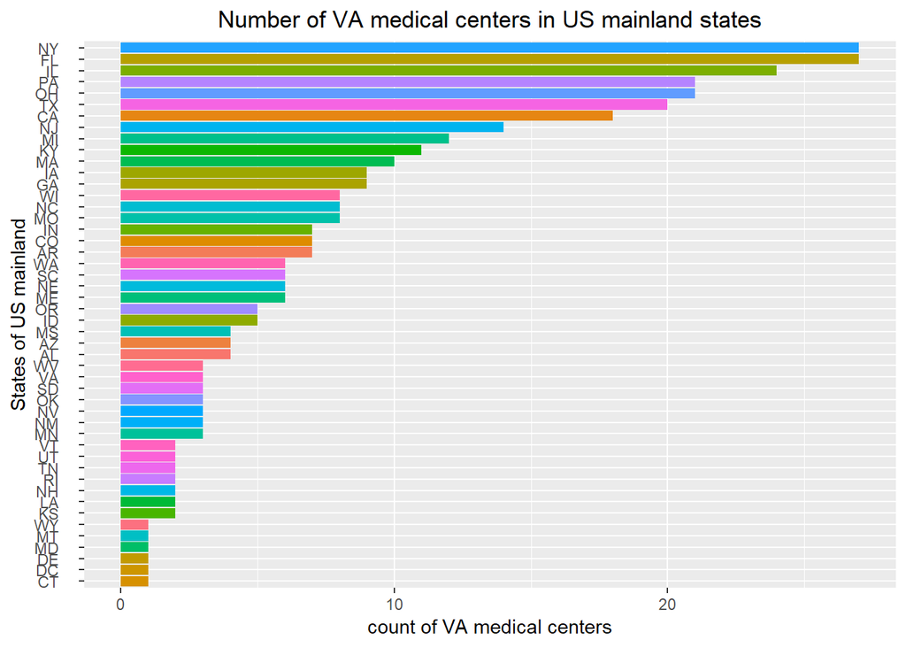

```r
theme_update(plot.title = element_text(hjust = 0.5))
#ggplot(data=mh2015.va.mc_us.count, aes(reorder(LST1,count),count)) + geom_bar(stat="identity", aes(fill = LST1)) + coord_flip()+ labs(title="Number of VA medical centers in US mainland states") + xlab("States of US mainland") + ylab("count of VA medical centers") + theme(legend.position="none")
ggplot(data=mh2015.va.mc_us.count, aes(reorder(LST,count),count)) + geom_bar(stat="identity", aes(fill = LST)) + coord_flip()+ labs(title="Number of VA medical centers in US mainland states") + xlab("States of US mainland") + ylab("count of VA medical centers") + theme(legend.position="none")
```

## Cleaning and Bringing in New Features

**a - Merge with statesize.csv**

This graph (1D) might be somewhat misleading, as bigger states may have more hospitals, but could be more sparsely located. Read statesize.csv into your R environment. This contains essentially a vector of square miles for each state.

load statesize file

```r
statesize <- read.csv('Data/statesize.csv', header=T)

str(statesize)
```

```
## 'data.frame':    50 obs. of  4 variables:
##  $ StateName: Factor w/ 50 levels "Alabama","Alaska",..: 1 2 3 4 5 6 7 8 9 10 ...
##  $ SqMiles  : int  50750 570374 113642 52075 155973 103730 4845 1955 53997 57919 ...
##  $ Abbrev   : Factor w/ 50 levels "AK","AL","AR",..: 2 1 4 3 5 6 7 8 9 10 ...
##  $ Region   : Factor w/ 4 levels "Midwest","Northeast",..: 3 4 4 3 4 4 2 3 3 3 ...
```

```r
dim(statesize)
```

```
## [1] 50  4
```

Merge VA medical centers in US mainland with statesize dataset

```r
mh2015.va.mc_us.statesize1 <- merge(mh2015.va.mc_us.count, statesize, by.x="LST", by.y="Abbrev")
dim(mh2015.va.mc_us.statesize1)
```

```
## [1] 0 5
```

```r
summary(mh2015.va.mc_us.statesize1$SqMiles)
```

```
##    Min. 1st Qu.  Median    Mean 3rd Qu.    Max.
##
```

Join didnot occur. We performed an inner join by not defining option ‘all’ in merge, defaults to FALSE. Dim shows 0 records merged . Another way to know this is ,Summary of the SqMiles has no data. In order to analyze this, we will print LST data from original dataset.

```r
# paste first few records from LST to see the data
head(paste(mh2015_puf$LST))
```

```
## [1] "AL    " "AL    " "AL    " "AL    " "AL    " "AL    "
```

It is clear from looking at data in LST that there are whitespaces in the values. In order to perform merge, we need to remove these whitespaces before merging with statesize dataset.

**b - correct the merge**

correct the problem with LST and merge with statesize dataset on Abbrev.

```r
#remove whitspaces
# trimws removes leading and/or trailing whitespaces from character strings, we prefer to remove from both leading and trailing

mh2015.va.mc_us.count$LST <- trimws(mh2015.va.mc_us.count$LST, which = c("both"))
```

Once the data is cleaned, we can perform merge again

```r
mh2015.va.mc_us.statesize <- merge(mh2015.va.mc_us.count, statesize, by.x="LST", by.y="Abbrev")

# list top records from the merged dataset
head(mh2015.va.mc_us.statesize)
```

```
##   LST count   StateName SqMiles    Region
## 1  AL     4     Alabama   50750     South
## 2  AR     7    Arkansas   52075     South
## 3  AZ     4     Arizona  113642      West
## 4  CA    18  California  155973      West
## 5  CO     7    Colorado  103730      West
## 6  CT     1 Connecticut    4845 Northeast
```

```r
#dimension of the merged dataset
dim(mh2015.va.mc_us.statesize)
```

```
## [1] 47  5
```

```r
#summary of the sqMiles data from the merged dataset
summary(mh2015.va.mc_us.statesize$SqMiles)
```

```
##    Min. 1st Qu.  Median    Mean 3rd Qu.    Max.
##    1045   37734   53997   61494   80720  261914
```

This time, inner join returned 47 rows. We have summary statistics of SqMiles data. So we can say that the join was performed correctly.

**c - Calculate new variable : VA_mc_per1000**

new variable will store VA hospitals per thousand square miles.

```r
mh2015.va.mc_us.statesize$va_mc_per1000 <- (mh2015.va.mc_us.statesize$count/mh2015.va.mc_us.statesize$SqMiles)*1000

# list top records from the merged dataset
head(mh2015.va.mc_us.statesize)
```

```
##   LST count   StateName SqMiles    Region va_mc_per1000
## 1  AL     4     Alabama   50750     South    0.07881773
## 2  AR     7    Arkansas   52075     South    0.13442151
## 3  AZ     4     Arizona  113642      West    0.03519825
## 4  CA    18  California  155973      West    0.11540459
## 5  CO     7    Colorado  103730      West    0.06748289
## 6  CT     1 Connecticut    4845 Northeast    0.20639835
```

```r
#dimension of the merged dataset
dim(mh2015.va.mc_us.statesize)
```

```
## [1] 47  6
```

```r
#summary of the va_mc_per1000 data from the merged dataset
summary(mh2015.va.mc_us.statesize$va_mc_per1000)
```

```
##    Min. 1st Qu.  Median    Mean 3rd Qu.    Max.
## 0.00687 0.05030 0.11611 0.25639 0.21424 1.91388
```

**d - Plot a barchart with Bar’s colors based on Region**

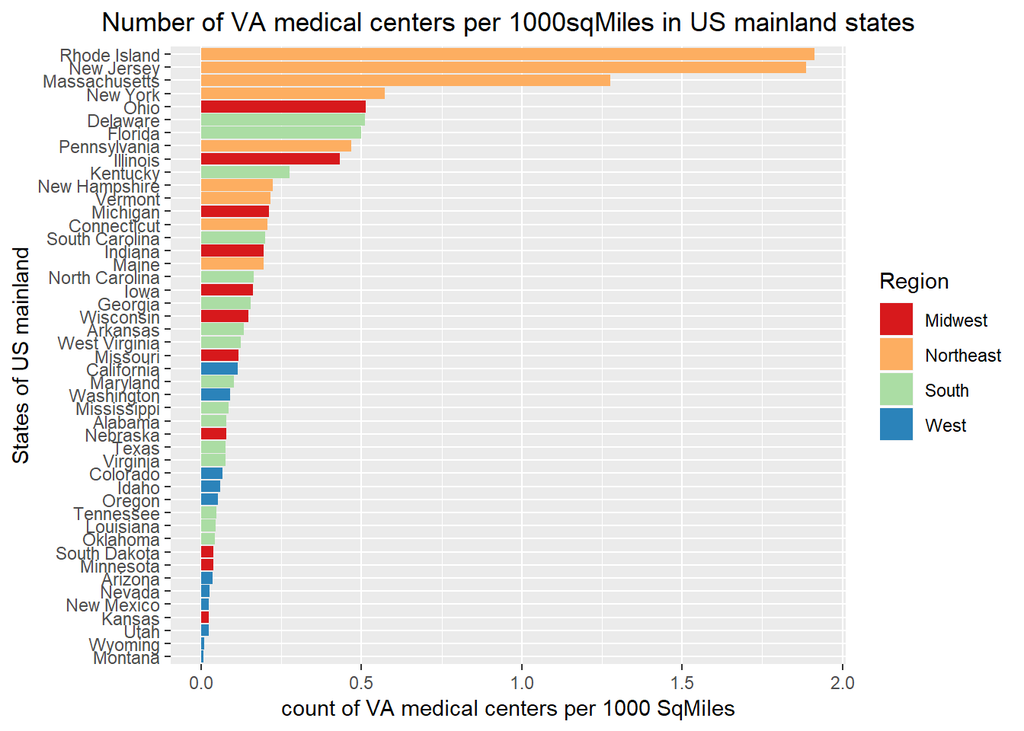

```r
ggplot(data=mh2015.va.mc_us.statesize, aes(reorder(StateName,va_mc_per1000),va_mc_per1000)) + geom_bar(stat="identity", aes(fill = Region)) + coord_flip()+ labs(title="Number of VA medical centers per 1000sqMiles in US mainland states") + xlab("States of US mainland") + ylab("count of VA medical centers per 1000 SqMiles") + scale_fill_brewer(palette="Spectral")
```

```r
  #scale_fill_manual(values=c("snow3","plum","lightblue","palegreen"))
```